# Machine Learning Course Project

M. Mili

25 mars 2019

# Overview

This study is about human activity. People tend to quantify their activity but rarely check how well they do it. The goal of this project is to predict the manner in which they did the exercise, using data from different captors.

Credits for the data collection:

Velloso, E.; Bulling, A.; Gellersen, H.; Ugulino, W.; Fuks, H. Qualitative Activity Recognition of Weight Lifting Exercises. Proceedings of 4th International Conference in Cooperation with SIGCHI (Augmented Human ’13) . Stuttgart, Germany: ACM SIGCHI, 2013.

# Data Analysis

A quick check of the data, shows that we have many missing values (‘#DIV/0!’, ‘’, ’NA’), so as a first step we’ll try to clean the data and keep only the variables which are at least 90% complete. Also the seven first columns are not useful for this analysis, so we need to discard them too. We’ll also use doParalell and snow to speed up the process.

```r
library("caret")
```

```r
library("corrplot")
library("doParallel")
library("snow")
workers=makeCluster(4,type="SOCK")
registerDoParallel(workers)
foreach(i=1:4) %dopar% Sys.getpid()
```

```
## [[1]]
## [1] 8144
##
## [[2]]
## [1] 13604
##
## [[3]]
## [1] 12612
##
## [[4]]
## [1] 1056
```

```r
set.seed(159)
training <- read.csv("./pml-training.csv",sep=",",na.strings=c('#DIV/0!', '', 'NA'))
testing <- read.csv("./pml-testing.csv",sep=",",na.strings=c('#DIV/0!', '', 'NA'))

colok <- NULL
training_clean <- training[-c(1:7,160)]
for(i in seq(1,ncol(training_clean)))
    if ((sum(is.na(training_clean[,i]))/nrow(training_clean)) < .1)
        colok <- c(colok,i)
training_clean <- training_clean[colok]
training_clean$classe <- training$classe
```

# Check Predictors Correlation

The number of predictors: 52 is high. Let’s check the correlation between them.

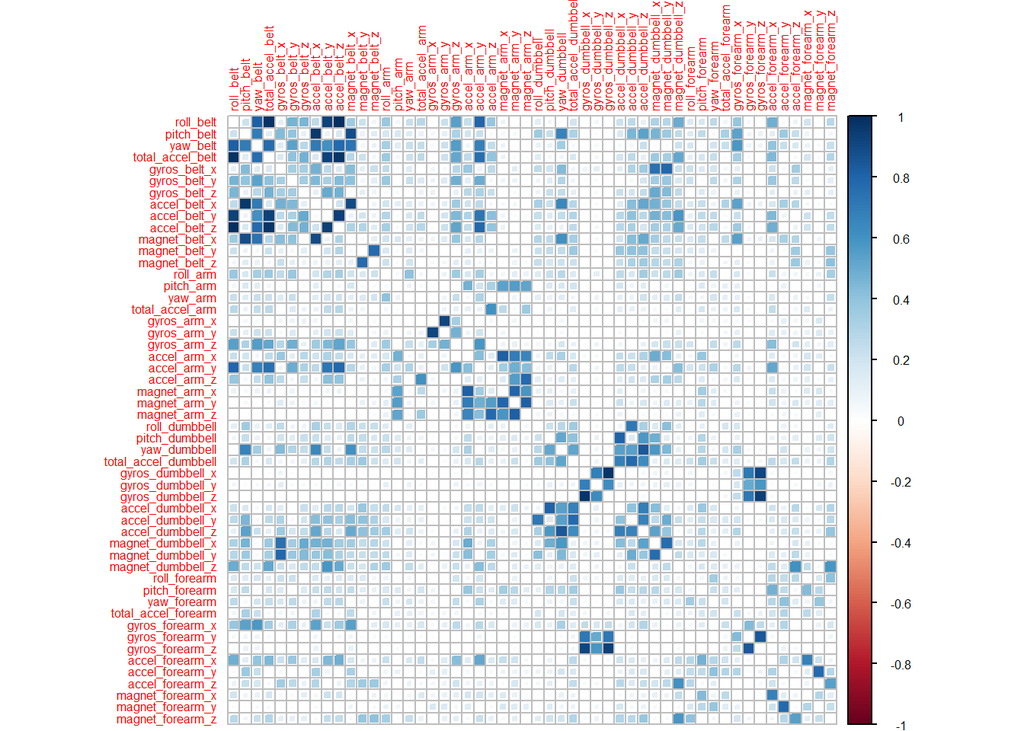

```r
matcor <- abs(cor(training_clean[,-53]))
diag(matcor) <- 0
corrplot(matcor,tl.cex=0.5,cl.cex=0.5,method="square")
```

# Reduce the Predictors

From the correlation matrix plot, we can see that many predictors are highly correlated. Using PCA seems to be a good idea to reduce them.

```r
pcapreproc <- preProcess(training_clean[,-53],method="pca",thresh = 0.95)
pcapreproc
```

```
## Created from 19622 samples and 52 variables
##
## Pre-processing:
##   - centered (52)
##   - ignored (0)
##   - principal component signal extraction (52)
##   - scaled (52)
##
## PCA needed 25 components to capture 95 percent of the variance
```

# Which Model

Obviously, it is a classification problem. For this the recommended model is Random Forest. We’ll also use repeated KFolds cross validation to optimize our model. Let’s try.

```r
control <- trainControl(method="repeatedcv", number=10, repeats=3)

model_rfpca <- train(classe~.,data=training_clean, method="rf", metric="Accuracy", trControl=control, preprocess = c(method="pca",thresh=0.95))
model_rfpca
```

```
## Random Forest
##
## 19622 samples
##    52 predictor
##     5 classes: 'A', 'B', 'C', 'D', 'E'
##
## No pre-processing
## Resampling: Cross-Validated (10 fold, repeated 3 times)
## Summary of sample sizes: 17660, 17662, 17659, 17659, 17659, 17659, ...
## Resampling results across tuning parameters:
##
##   mtry  Accuracy   Kappa
##    2    0.9953625  0.9941336
##   27    0.9952093  0.9939399
##   52    0.9904018  0.9878580
##
## Accuracy was used to select the optimal model using the largest value.
## The final value used for the model was mtry = 2.
```

```r
predict_rfpca <- predict(model_rfpca,newdata=training_clean)
confusionMatrix(predict_rfpca,training_clean$classe)
```

```
## Confusion Matrix and Statistics
##
##           Reference
## Prediction    A    B    C    D    E
##          A 5580    0    0    0    0
##          B    0 3797    0    0    0
##          C    0    0 3422    0    0
##          D    0    0    0 3216    0
##          E    0    0    0    0 3607
##
## Overall Statistics
##
##                Accuracy : 1
##                  95% CI : (0.9998, 1)
##     No Information Rate : 0.2844
##     P-Value [Acc > NIR] : < 2.2e-16
##
##                   Kappa : 1
##  Mcnemar's Test P-Value : NA
##
## Statistics by Class:
##
##                      Class: A Class: B Class: C Class: D Class: E
## Sensitivity            1.0000   1.0000   1.0000   1.0000   1.0000
## Specificity            1.0000   1.0000   1.0000   1.0000   1.0000
## Pos Pred Value         1.0000   1.0000   1.0000   1.0000   1.0000
## Neg Pred Value         1.0000   1.0000   1.0000   1.0000   1.0000
## Prevalence             0.2844   0.1935   0.1744   0.1639   0.1838
## Detection Rate         0.2844   0.1935   0.1744   0.1639   0.1838
## Detection Prevalence   0.2844   0.1935   0.1744   0.1639   0.1838
## Balanced Accuracy      1.0000   1.0000   1.0000   1.0000   1.0000
```

The accuracy of our model is quite good. We can rely on it.

# Clean Testing data set

We need to reshape the testing data set the same way as we did for the training one: We need to keep only the same columns.

```r
testing_clean <- testing[names(training_clean[,-53])]
```

# Predict on testing data set

Using our model we can predict on the testing data set:

```r
testing_prediction <- predict(model_rfpca,newdata=testing_clean)
testing_prediction
```

```
##  [1] B A B A A E D B A A B C B A E E A B B B
## Levels: A B C D E
```